[figure not shown]

# Android Fundamentals

## Unit 1: Get started

### 1.4 Text and scrolling views

- Introduction
- What you'll learn
- What you'll do

#### Tasks

- Task 1: Add and edit TextView elements
- Task 2: Add a ScrollView and an active web link
- Task 3: Scroll multiple elements

#### Coding Challenge

[Vocabulary words and concepts glossary](https://developers.google.com/android/for-all/vocab-words/)

1. Introduction

If you have more information than fits on the device's display, you can create a scrolling view so that the user can scroll vertically by swiping up or down, or horizontally by swiping right or left.

You would typically use a scrolling view for news stories, articles, or any lengthy text that doesn't completely fit on the display. You can also use a scrolling view to enable users to enter multiple lines of text, or to combine UI elements (such as a text field and a button) within a scrolling view.

> You should be able to:
> - Create a Hello World app with Android Studio.
> - Run an app on an emulator or a device.
> - Implement a TextView in a layout for an app.
> - Create and use string resources.
1. What you'll learn
   - How to use XML code to add multiple TextView elements.
   - How to use XML code to define a scrolling View.
   - How to style the TextView background color and text color.
   - How to include a web link in the text.
1. What you'll do
   - Create the ScrollingText app.
   - Change the ConstraintLayout ViewGroup to RelativeLayout.
   - Add two TextView elements for the article heading and subheading.
   - Use TextAppearance styles and colors for the article heading and subheading.
   - Use HTML tags in the text string to control formatting.
   - Use the lineSpacingExtra attribute to add line spacing for readability.
   - Add a ScrollView to the layout to enable scrolling a TextView element.
   - Add the autoLink attribute to enable URLs in the text to be active and clickable.

## Task 1: Add and edit TextView elements

#### 1.1 Create the project and TextView elements

#### 1.2 Add the text of the article

#### 1.3 Run the app

## Task 2: Add a ScrollView and an active web link

#### 2.1 Add the autoLink attribute for active web links

#### 2.2 Add a ScrollView to the layout

#### 2.3 Run the app

## Task 3: Scroll multiple elements

#### 3.1 Add a LinearLayout to the ScrollView

#### 3.2 Move UI elements within the LinearLayout

#### 2.3 Run the app

## [Solution code](https://github.com/google-developer-training/android-fundamentals-apps-v2/tree/master/ScrollingText)

## Coding challenge

**Challenge:** Add another UI element—a Button—to the LinearLayout inside the ScrollView so that it scrolls with the text.

1. Make the Button appear below the article. The user scrolls to the end of the article to see the Button.
2. Use the text Add Comment for the Button. For this challenge, there is no need to create a button-handling method; all you have to do is put the Button element in the proper place in the layout.

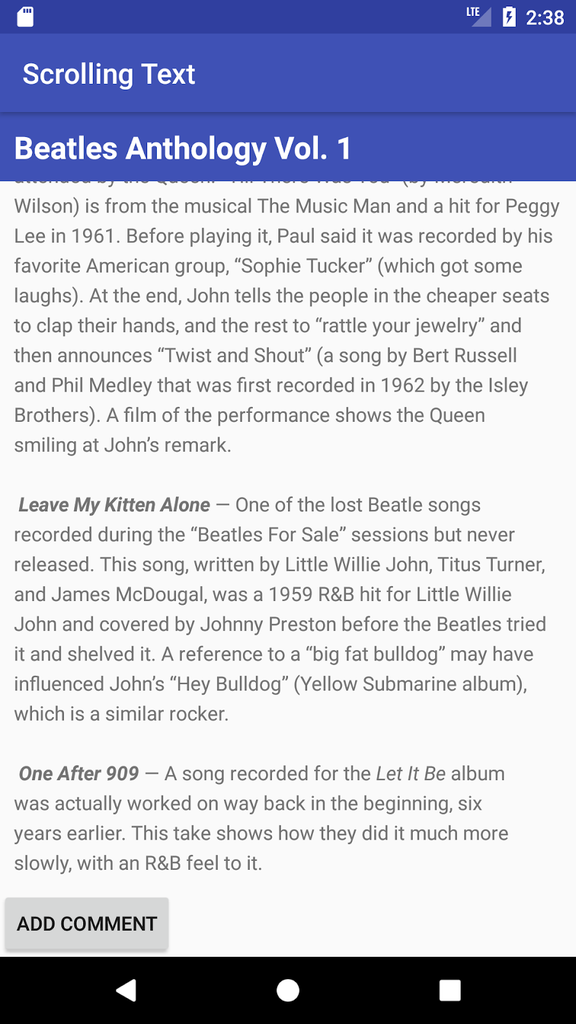

## [Challenge solution code](https://github.com/google-developer-training/android-fundamentals-apps-v2/tree/master/ScrollingTextChallenge)